# Project Python Foundations: FoodHub Data Analysis

# Observation on restaurant_name:

- this not readable. So can't do analysis

#### Observation on OrderID :

```python
df.head()
```

|  | order_id | customer_id | restaurant_name | cuisine_type | cost_of_the_order | day_of_the_week | rating | food_preparation_time | delivery_time |
| --- | --- | --- | --- | --- | --- | --- | --- | --- | --- |
| 0 | 1477147 | 337525 | Hangawi | Korean | 30.75 | Weekend | Not given | 25 | 20 |
| 1 | 1477685 | 358141 | Blue Ribbon Sushi Izakaya | Japanese | 12.08 | Weekend | Not given | 25 | 23 |
| 2 | 1477070 | 66393 | Cafe Habana | Mexican | 12.23 | Weekday | 5 | 23 | 28 |
| 3 | 1477334 | 106968 | Blue Ribbon Fried Chicken | American | 29.20 | Weekend | 3 | 25 | 15 |
| 4 | 1478249 | 76942 | Dirty Bird to Go | American | 11.59 | Weekday | 4 | 25 | 24 |

```python
df['order_id'].nunique() #Find unique Order ID =1898
```

```
1898
```

```python
df['customer_id'].nunique() # Find unquie Customer IDs = 1200 out of 1898
```

```
1200
```

## Observation on Day of week:

- Weekend are likely to order food online while weekdays.

```python
df['day_of_the_week'].nunique() #Total number of unique day type is. 2
```

```
2
```

```
(array([0, 1]), [Text(0, 0, 'Weekend'), Text(1, 0, 'Weekday')])
```

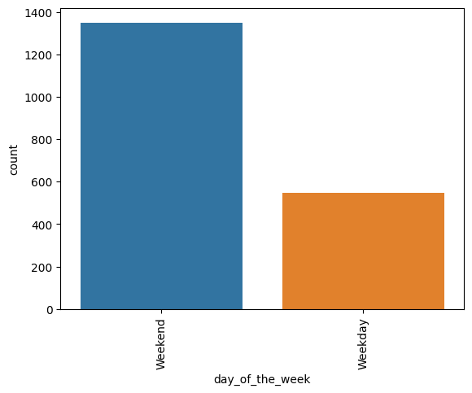

```python
sns.countplot(data=df,x='day_of_the_week')
plt.xticks(rotation = 90)
```

### **Question 7**: Which are the top 5 restaurants in terms of the number of orders received? [1 mark]

```python
df.head()
```

|  | order_id | customer_id | restaurant_name | cuisine_type | cost_of_the_order | day_of_the_week | rating | food_preparation_time | delivery_time |
| --- | --- | --- | --- | --- | --- | --- | --- | --- | --- |
| 0 | 1477147 | 337525 | Hangawi | Korean | 30.75 | Weekend | Not given | 25 | 20 |
| 1 | 1477685 | 358141 | Blue Ribbon Sushi Izakaya | Japanese | 12.08 | Weekend | Not given | 25 | 23 |
| 2 | 1477070 | 66393 | Cafe Habana | Mexican | 12.23 | Weekday | 5 | 23 | 28 |
| 3 | 1477334 | 106968 | Blue Ribbon Fried Chicken | American | 29.20 | Weekend | 3 | 25 | 15 |
| 4 | 1478249 | 76942 | Dirty Bird to Go | American | 11.59 | Weekday | 4 | 25 | 24 |

```python
# Write the code here
df.restaurant_name.value_counts() # give me count of all restaurant

df0 = df.restaurant_name.value_counts().head() # only gives 5 top most restaurants

df0
```

```
Shake Shack                  219
The Meatball Shop            132
Blue Ribbon Sushi            119
Blue Ribbon Fried Chicken     96
Parm                          68
Name: restaurant_name, dtype: int64
```

### **Question 8**: Which is the most popular cuisine on weekends? [1 mark]

```python
# Write the code here
df0 = (df.groupby(['cuisine_type','day_of_the_week'])['day_of_the_week'].agg(['count'])) # this will gives me value  count of each cuisine on week days and weekends but not sorted
df1 = (df.groupby(['cuisine_type','day_of_the_week'])['day_of_the_week'].agg(['count'])).sort_values(by='count', ascending=False).reset_index().drop_duplicates('cuisine_type', keep='first') # this will give me value count on each cuisine on weekend in sorted order and removed duplicates
df1
```

|  | cuisine_type | day_of_the_week | count |
| --- | --- | --- | --- |
| 0 | American | Weekend | 415 |
| 1 | Japanese | Weekend | 335 |
| 2 | Italian | Weekend | 207 |
| 4 | Chinese | Weekend | 163 |
| 7 | Mexican | Weekend | 53 |
| 9 | Indian | Weekend | 49 |
| 10 | Middle Eastern | Weekend | 32 |
| 11 | Mediterranean | Weekend | 32 |
| 15 | Thai | Weekend | 15 |
| 17 | French | Weekend | 13 |
| 18 | Korean | Weekend | 11 |
| 19 | Southern | Weekend | 11 |
| 20 | Spanish | Weekend | 11 |
| 24 | Vietnamese | Weekend | 4 |

#### Observations:

- All cuisine on weekend are more order than weekdays for American, Japanese, Italian, Chinese, Mexican, Indian.
- American cuisine is the most popular cuisine while Vietnamese are the least popular one.
- some cuisines are equally populare like Middle Eastern and Mediterranean or Korean, Southern and Spenish.

### **Question 9**: What percentage of the orders cost more than 20 dollars? [2 marks]

```python
# Write the code here
df20per = df[df['cost_of_the_order']>20].value_counts().count()
percentage = (df20per/df['cost_of_the_order'].count()) * 100
percentage
```

```
29.24130663856691
```

```python
df_20g = df[df['cost_of_the_order']>20]
percentage = (df_20g.shape[0]/df.shape[0])*100
percentage
```

```
29.24130663856691
```

#### Observations:

Total 29.24130663856691% are the percentage of the orders cost more than 20 dollars

### **Question 10**: What is the mean order delivery time? [1 mark]

```python
# Write the code here
#Statistical Summery
#df.describe()
meantime = df['delivery_time'].mean()
#round(meantime,2)
meantime
```

```
24.161749209694417
```

#### Observations:

24.161749 minute is mean order delivery time.

### **Question 11:** The company has decided to give 20% discount vouchers to the top 3 most frequent customers. Find the IDs of these customers and the number of orders they placed. [1 mark]

```python
# Write the code here
df['customer_id'].value_counts().head(3)
```

```
52832    13
47440    10
83287     9
Name: customer_id, dtype: int64
```

#### Observations:

Cutomer id

1. 52832 count = 13
2. 47440 count = 10
3. 83287 count = 9

are the winner :-)